# Tarefa Aula 1 – Exploração de SNA em R

Novembro de 2019

# Alunos / ID (matrícula)

- Daniel Campos / A57635769
- Leandro Daniel / A57622988
- Rodrigo Goncalves / A57566093
- Ygor Lima / A57549661

# Enunciado (parte 1)

- Explore as rotinas Exemplo Rede.R e Exemplo Rede Two Mode.R . Rode os códigos na plataforma R utilizando como base as tabelas Rede One Mode_Tarefa Aula 1_Berrini T1.xlsx e Rede Two Mode_Tarefa Aula 1_Berrini T1.xlsx. (atenção: não são as mesmas bases trabalhadas em sala).
- Faça pequenas modificações na tabela e veja seus resultados.
- Inclua outras análises em seu código (usando as extensões sna, network ou igraph) e comente os resultados (seja criativo!).
- Compile as saídas dos códigos (conteúdo das variáveis, gráficos, tabelas) em um documento Word (usando o modelo deste documento) e comente seus resultados (principalmente as medidas de centralidade), análises, potenciais implicações gerenciais, etc, conforme discutido em sala na Aula 1.

## Explorando as rotinas de exemplo para rede one mode

Como primeiro passo para o exercício proposto, vamos carregar os dados da planilha Excel **Rede One Mode_Tarefa Aula 1_Berrini T1.xlsx**. Incialmente, removeremos a primeira coluna que possui os nomes dos nós e vamos atribui-la às linhas.

```r
# carregando a planilha com os dados do exercício
rede_one_mode <- read_xlsx("../../data/raw/Rede One Mode_Tarefa Aula 1_Berrini T1.xlsx",
                           sheet = "Exemplo Rede") %>% as.data.frame()

# removendo a coluna com os nomes dos nós
grede_one_mode <- rede_one_mode[,2:25]

# atribuindo o nome dos nós às linhas
rownames(grede_one_mode) <- rede_one_mode[,1]
```

Podemos então, visualizar a rede sob a forma de um grafo.

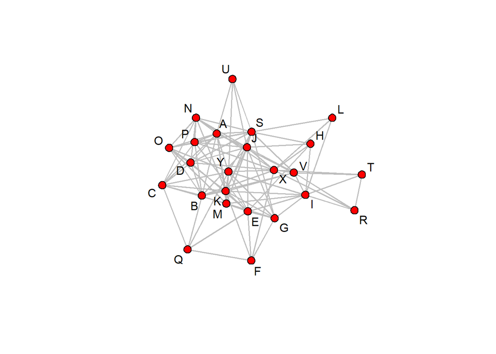

```r
gplot(grede_one_mode,
      gmode = "graph",
      displaylabels = TRUE,
      edge.col = "gray",
      usearrows = FALSE)
```

O **R** oferece várias packages para manipulação e geração de visualizações de redes. Abaixo, vemos um exemplo utilizando a library **visNetwork**.

```r
g_one_mode <- igraph::graph_from_adjacency_matrix(as.matrix(grede_one_mode))

visIgraph(g_one_mode)
```

[interactive chart not shown]

A **SNA**, do inglês Systems Network Analysis (Análise de Sistemas de Redes), dispõe de um conjunto de métricas que auxiliam na compreensão da dinâmica dos relacionamentos existentes nas redes analisadas. Dentre elas, destacam-se as métricas de Centralidade (Centrality), que permitem a avaliação da importância de um nó (individuo/ação/postagem) dentro da rede. Na sequência, vamos explorar as métricas de centralidade: **degree**, **closeness** e **betweenness**.

A **Centralidade de Grau** (Degree Centrality) representa o número de ligações que um nó possui (degree), dividido pelo número de ligações possíveis.

Definimos como **Centralidade de Proximidade** (Closeness Centrality) a medida do comprimento médio dos caminhos mais curtos de um vértice para cada um dos outros vértices de um grafo.

A chamada **Centralidade de Intermediação** (Betweenness Centrality) representa a quantidade de vezes que um determinado nó aparece no caminho geodésico entre dois nós da rede.

A seguir, exploraremos as métricas de centralidade para a rede one mode.

```r
metricas_one_mode <- cbind(label = rownames(grede_one_mode),
                           degree = degree(grede_one_mode, gmode = "graph", cmode = "indegree"),
                           closeness = closeness(grede_one_mode, gmode = "graph"),
                           betweenness = betweenness(grede_one_mode, gmode = "graph"))

table_output <- flextable(as.data.frame(metricas_one_mode))
table_output <- fontsize(table_output, part = "all", size = 8)
table_output <- autofit(table_output)
table_output
```

| label | degree | closeness | betweenness |
| --- | --- | --- | --- |
| A | 13 | 0.696969696969697 | 8.30959595959596 |
| B | 10 | 0.638888888888889 | 7.648556998557 |
| C | 9 | 0.560975609756098 | 4.38611111111111 |
| D | 9 | 0.621621621621622 | 3.3711038961039 |
| E | 11 | 0.657142857142857 | 12.5170634920635 |
| F | 5 | 0.547619047619048 | 2.03333333333333 |
| G | 8 | 0.605263157894737 | 2.42619047619048 |
| H | 5 | 0.547619047619048 | 0.892857142857143 |
| I | 10 | 0.638888888888889 | 18.4192640692641 |
| J | 14 | 0.71875 | 14.8384920634921 |
| K | 14 | 0.71875 | 15.6029220779221 |
| L | 3 | 0.511111111111111 | 0.434523809523809 |
| M | 10 | 0.638888888888889 | 3.95324675324675 |
| N | 9 | 0.621621621621622 | 2.32031024531025 |
| O | 9 | 0.58974358974359 | 1.99563492063492 |
| P | 9 | 0.621621621621622 | 3.3711038961039 |
| Q | 5 | 0.522727272727273 | 1.68571428571429 |
| R | 4 | 0.5 | 0.166666666666667 |
| S | 14 | 0.71875 | 20.1944444444444 |
| T | 4 | 0.5 | 0.166666666666667 |
| U | 4 | 0.511111111111111 | 0.125 |
| V | 9 | 0.621621621621622 | 11.349025974026 |
| X | 12 | 0.676470588235294 | 29.5321067821068 |
| Y | 12 | 0.676470588235294 | 16.2600649350649 |

## Explorando as rotinas de exemplo para rede two mode

Como primeiro passo para o exercício proposto, vamos carregar os dados da planilha Excel **Rede Two Mode_Tarefa Aula 1_Berrini T1.xlsx**. Faremos um tratamento semelhante ao realizado para a rede anterior.

```r
# carregando a planilha com os dados do exercício
rede_two_mode <- read_xlsx("../../data/raw/Rede Two Mode_Tarefa Aula 1_Berrini T1.xlsx",
                           sheet = "Rede 2-mode") %>% as.data.frame
```

```
## * `` -> ...1
```

```r
names(rede_two_mode)[1] <- 'nome'

# removendo a coluna com os nomes dos nós
grede_two_mode <- rede_two_mode[,2:15]

# atribuindo o nome dos nós às linhas
rownames(grede_two_mode) <- rede_two_mode[,1]
```

Visualizando a rede sob a forma de um grafo.

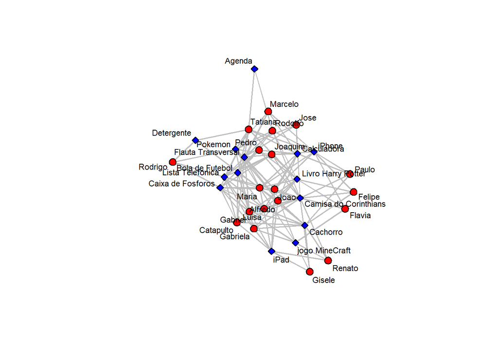

```r
gplot(grede_two_mode, gmode = "twomode",
      displaylabels = TRUE,
      edge.col = "gray",
      label.cex = 0.7,
      usearrows = FALSE)
```

A seguir, exploraremos as métricas de centralidade para a rede two mode.

```r
metricas_two_mode <- cbind(degree = degree(grede_two_mode, gmode = "twomode", cmode = "indegree"),
                           closeness = closeness(grede_two_mode, gmode = "twomode"),
                           betweenness = betweenness(grede_two_mode, gmode = "twomode"))

table_output <- flextable(as.data.frame(metricas_two_mode))
table_output <- fontsize(table_output, part = "all", size = 8)
table_output <- autofit(table_output)
table_output
```

| degree | closeness | betweenness |
| --- | --- | --- |
| 9.000 | 0.533 | 40.030 |
| 13.000 | 0.615 | 105.369 |
| 4.000 | 0.457 | 4.912 |
| 4.000 | 0.444 | 6.623 |
| 6.000 | 0.485 | 10.871 |
| 7.000 | 0.500 | 17.610 |
| 5.000 | 0.444 | 6.924 |
| 8.000 | 0.516 | 27.120 |
| 9.000 | 0.533 | 28.496 |
| 8.000 | 0.516 | 26.748 |
| 4.000 | 0.444 | 6.676 |
| 7.000 | 0.500 | 18.868 |
| 4.000 | 0.400 | 6.585 |
| 10.000 | 0.552 | 45.029 |
| 8.000 | 0.516 | 46.262 |
| 4.000 | 0.444 | 5.793 |
| 4.000 | 0.421 | 4.673 |
| 10.000 | 0.516 | 68.737 |
| 4.000 | 0.421 | 4.673 |
| 9.000 | 0.492 | 47.426 |
| 8.000 | 0.464 | 26.139 |
| 11.000 | 0.525 | 54.598 |
| 7.000 | 0.451 | 23.927 |
| 16.000 | 0.627 | 156.837 |
| 11.000 | 0.525 | 47.002 |
| 10.000 | 0.508 | 39.863 |
| 11.000 | 0.525 | 52.264 |
| 10.000 | 0.508 | 41.988 |
| 10.000 | 0.508 | 45.834 |
| 3.000 | 0.416 | 4.236 |
| 2.000 | 0.376 | 0.546 |
| 10.000 | 0.492 | 50.232 |
| 10.000 | 0.508 | 51.107 |

## Aplicando modificações na rede two mode e analisando os resultados